# Tutorial 4: Linear and non-linear probability models

Forschungspraktikum I und II: Vergleichende Sozialforschung mit Mehrebenenmodellen in R

Dr. Christian Czymara (Sociology with Focus on Quantitative Methods for Social Research, Goethe University Frankfurt)

We will examine the impact of satisfaction with democracy on voting behavior in Latvia (LV), drawing upon data from the fourth wave of the ESS (2008/09).

## 1. Importing data

Import the file `ESS4e04_5_LV.dta` by assigning it to an object `ESS08_LV` using `read_dta()`.

```r
setwd("C:/Users/czymara.local/Nextcloud/teaching/FoP HLM/_R/04_probability_models")

library(haven)

ESS08_LV <- read_dta("ESS4e04_5_LV.dta")
```

## 2. Data preparation

Based on the variable `vote`, generate a binary variable `vote_bin` with value 1 = voted in last election, and 0 = did not vote in last election (but would have been eligible). Note that I already took care of listwise deletion for this tutorial.

```r
# show labels
attr(ESS08_LV$vote, "labels")
```

```
##                  Yes                   No Not eligible to vote
##                    1                    2                    3
##              Refusal           Don't know            No answer
##                   NA                   NA                   NA
```

```r
# recode
ESS08_LV$vote_bin <- ifelse(ESS08_LV$vote == 1, 1,
                            ifelse(ESS08_LV$vote == 2, 0,
                                   NA))

# compare
table(ESS08_LV$vote_bin, ESS08_LV$vote, useNA = "always")
```

```
##
##           1    2    3 <NA>
##   0       0  674    0    0
##   1    1139    0    0    0
##   <NA>    0    0  150   17
```

## 3. Logistic regression

### a) Null model

Run an empty logit model (i. e., one without any explanatory variables) using the `glm()` function. Interpret the logit coefficient. How large is the share of those who voted in the last election? What is the probability to have voted in the last election?

```r
# estimate model
logit_m0 <- glm(vote_bin ~ 1,
                data = ESS08_LV,
                family = "binomial"(link = "logit"))

# show results
summary(logit_m0)
```

```
##
## Call:
## glm(formula = vote_bin ~ 1, family = binomial(link = "logit"),
##     data = ESS08_LV)
##
## Deviance Residuals:
##     Min       1Q   Median       3Q      Max
## -1.4068  -1.4068   0.9642   0.9642   0.9642
##
## Coefficients:
##             Estimate Std. Error z value Pr(>|z|)
## (Intercept)   0.5247     0.0486    10.8   <2e-16 ***
## ---
## Signif. codes:  0 '***' 0.001 '**' 0.01 '*' 0.05 '.' 0.1 ' ' 1
##
## (Dispersion parameter for binomial family taken to be 1)
##
##     Null deviance: 2392.7  on 1812  degrees of freedom
## Residual deviance: 2392.7  on 1812  degrees of freedom
##   (167 Beobachtungen als fehlend gelöscht)
## AIC: 2394.7
##
## Number of Fisher Scoring iterations: 4
```

```r
# share of voters / probability to have voted
exp(logit_m0$coefficients)/(1+exp(logit_m0$coefficients))
```

```
## (Intercept)
##   0.6282405
```

```r
# compare
prop.table(table(ESS08_LV$vote_bin))
```

```
##
##         0         1
## 0.3717595 0.6282405
```

```r
round(prop.table(table(ESS08_LV$vote_bin))[2], 10) == round(exp(logit_m0$coefficients)/(1+exp(logit_m0$coefficients)), 10) # both practically identical
```

```
##    1
## TRUE
```

### b) Adding predictor

Add the explanatory variable `stfdem` (satisfaction with democracy) to the model and interpret the logit coefficient of the effect.

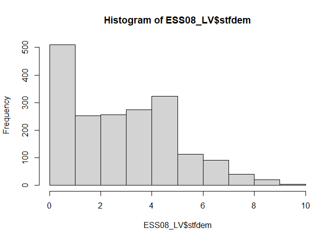

```r
# explore variable
hist(ESS08_LV$stfdem)
```

```r
attr(ESS08_LV$stfdem, "labels")
```

```
## Extremely dissatisfied                      1                      2
##                      0                      1                      2
##                      3                      4                      5
##                      3                      4                      5
##                      6                      7                      8
##                      6                      7                      8
##                      9    Extremely satisfied                Refusal
##                      9                     10                     NA
##             Don't know              No answer
##                     NA                     NA
```

```r
# run model
logit_m1 <- glm(vote_bin ~ stfdem,
                data = ESS08_LV,
                family = "binomial"(link = "logit"))

# show results

# logit
summary(logit_m1)
```

```
##
## Call:
## glm(formula = vote_bin ~ stfdem, family = binomial(link = "logit"),
##     data = ESS08_LV)
##
## Deviance Residuals:
##     Min       1Q   Median       3Q      Max
## -1.4831  -1.4082   0.9390   0.9549   0.9791
##
## Coefficients:
##             Estimate Std. Error z value Pr(>|z|)
## (Intercept)  0.48607    0.08687   5.595  2.2e-08 ***
## stfdem       0.02088    0.02205   0.947    0.344
## ---
## Signif. codes:  0 '***' 0.001 '**' 0.01 '*' 0.05 '.' 0.1 ' ' 1
##
## (Dispersion parameter for binomial family taken to be 1)
##
##     Null deviance: 2279.8  on 1736  degrees of freedom
## Residual deviance: 2278.9  on 1735  degrees of freedom
##   (243 Beobachtungen als fehlend gelöscht)
## AIC: 2282.9
##
## Number of Fisher Scoring iterations: 4
```

### c) Odds ratios and AMEs

Report the coefficient of 3.b) as odds ratio. Then calculate it as the average marginal effect (AME). Use the [`margins` package](https://cran.r-project.org/web/packages/margins/vignettes/Introduction.html#Average_Marginal_Effects_and_Average_Partial_Effects) for the AME (if you have worked with Stata before, the logic of the margins package should be pretty familiar to you).

```r
# odds ratio
exp(logit_m1$coefficients)
```

```
## (Intercept)      stfdem
##    1.625908    1.021100
```

```r
# average marginal effect

# install and load margins
if(!require(margins)){
    install.packages("margins")
    library(margins)
  }

# check help
?margins

margins(logit_m1)
```

```
##    stfdem
##  0.004837
```

### d) Adding control variables

Add the confounding variables age (`agea`), education (`edulvla`), and gender (`gndr`). Compare the coefficient of `stfdem` to 3.b) and interpret differences between both models.

```r
logit_m2 <- glm(vote_bin ~ stfdem + agea + factor(edulvla) + gndr,
                data = ESS08_LV,
                family="binomial"(link = "logit"))

summary(logit_m2)
```

```
##
## Call:
## glm(formula = vote_bin ~ stfdem + agea + factor(edulvla) + gndr,
##     family = binomial(link = "logit"), data = ESS08_LV)
##
## Deviance Residuals:
##     Min       1Q   Median       3Q      Max
## -2.1577  -1.1580   0.7194   0.9407   1.7095
##
## Coefficients:
##                   Estimate Std. Error z value Pr(>|z|)
## (Intercept)      -2.107449   0.385714  -5.464 4.66e-08 ***
## stfdem            0.044612   0.023374   1.909  0.05631 .
## agea              0.029119   0.003082   9.449  < 2e-16 ***
## factor(edulvla)2  0.204447   0.306541   0.667  0.50480
## factor(edulvla)3  0.922110   0.295100   3.125  0.00178 **
## factor(edulvla)5  1.564562   0.309188   5.060 4.19e-07 ***
## gndr              0.136921   0.108210   1.265  0.20575
## ---
## Signif. codes:  0 '***' 0.001 '**' 0.01 '*' 0.05 '.' 0.1 ' ' 1
##
## (Dispersion parameter for binomial family taken to be 1)
##
##     Null deviance: 2279.8  on 1736  degrees of freedom
## Residual deviance: 2119.1  on 1730  degrees of freedom
##   (243 Beobachtungen als fehlend gelöscht)
## AIC: 2133.1
##
## Number of Fisher Scoring iterations: 4
```

```r
# show both models in a tbal
library(sjPlot)

tab_model(logit_m1, logit_m2,
          show.se = TRUE,
          digits = 3
          )
```

|  | vote bin |  |  |  | vote bin |  |  |  |
| --- | --- | --- | --- | --- | --- | --- | --- | --- |
| Predictors | Odds Ratios | std. Error | CI | p | Odds Ratios | std. Error | CI | p |
| (Intercept) | 1.626 | 0.141 | 1.372 – 1.929 | **<0.001** | 0.122 | 0.047 | 0.057 – 0.258 | **<0.001** |
| How satisfied with the way democracy works in country | 1.021 | 0.023 | 0.978 – 1.066 | 0.344 | 1.046 | 0.024 | 0.999 – 1.095 | 0.056 |
| Age of respondent,calculated |  |  |  |  | 1.030 | 0.003 | 1.023 – 1.036 | **<0.001** |
| factor(edulvla)2 |  |  |  |  | 1.227 | 0.376 | 0.670 – 2.239 | 0.505 |
| factor(edulvla)3 |  |  |  |  | 2.515 | 0.742 | 1.406 – 4.491 | **0.002** |
| factor(edulvla)5 |  |  |  |  | 4.781 | 1.478 | 2.603 – 8.783 | **<0.001** |
| Gender |  |  |  |  | 1.147 | 0.124 | 0.927 – 1.417 | 0.206 |
| Observations | 1737 |  |  |  | 1737 |  |  |  |
| R<sup>2</sup> Tjur | 0.001 |  |  |  | 0.094 |  |  |  |

## 4. Predicting probabilities

### a) Prediction for women

Based on the coefficients of model 3.d), predict the probability to vote for different (hypothetical) persons. The formula for probabilities is $pr(y=1 | x)=\frac{e^{\beta_{0} + \beta_{1}x_{1} + \cdots + \beta_{k}x_{k}}}{1+e^{\beta_{0} + \beta_{1}x_{1} + \cdots + \beta_{k}x_{k}}}$, with $k$ being the number of variables in the model (see slide 31 of the lecture). Alternatively, use the `predict()` function. Predict the probability for a *woman* who is…

- 60 years old, has tertiary education and highest satisfaction with democracy
- 20 years old, has lowest education and lowest satisfaction with democracy
- Calculate the difference between both

```r
# 60 old etc. WOMEN

# with formula
# numerator:
exp(logit_m2$coefficients[1] # intercept
    + logit_m2$coefficients[7]*2 # woman
    +  logit_m2$coefficients[3]*60 # age
    + logit_m2$coefficients[6] # highest education
    + logit_m2$coefficients[2]*10 # max satisfaction with democ
    )/
  # denominator:
  (1+exp(logit_m2$coefficients[1] # intercept
             + logit_m2$coefficients[7]*2 # woman
             +  logit_m2$coefficients[3]*60 # age
             + logit_m2$coefficients[6] # highest education
             + logit_m2$coefficients[2]*10 # max satisfaction with democ
    ))
```

```
## (Intercept)
##   0.8726048
```

```r
# using predict
women_pred_1 <- predict(logit_m2, with(ESS08_LV,
                                       list(gndr = 2,
                                            agea = 60,
                                            edulvla = 5,
                                            stfdem = 10)),
                        type="response")
women_pred_1
```

```
##         1
## 0.8726048
```

```r
# 20 old etc. WOMEN
women_pred_2 <- predict(logit_m2, with(ESS08_LV,
                                       list(gndr = 2,
                                            agea = 20,
                                            edulvla = 1,
                                            stfdem = 0)),
                        type="response")
women_pred_2
```

```
##         1
## 0.2224863
```

```r
# difference for WOMEN
diff_woman <- women_pred_1 - women_pred_2
```

### b) Prediction for men

Do the same but for a *man* who is…

- 60 years old, has tertiary education and highest satisfaction with democracy
- 20 years old, has lowest education and lowest satisfaction with democracy
- Calculate the difference between both
- Then compare the difference of 4.a) with the differences in 4.b)

```r
# 60 old etc. MEN
men_pred_1 <- predict(logit_m2, with(ESS08_LV,
                                     list(gndr = 1,
                                          agea = 60,
                                          edulvla = 5,
                                          stfdem = 10)),
                      type="response")
men_pred_1
```

```
##         1
## 0.8565919
```

```r
# 20 old etc. MEN
# with formula
# numerator:
exp(logit_m2$coefficients[1] # intercept
    + logit_m2$coefficients[7]*1 # man
    +  logit_m2$coefficients[3]*20 # age
    # + logit_m2$coefficients # lowest education = reference category
    + logit_m2$coefficients[2]*0 # min satisfaction with democ
    )/
  # denominator:
  (1+exp(logit_m2$coefficients[1] # intercept
         + logit_m2$coefficients[7]*1 # man
         +  logit_m2$coefficients[3]*20 # age
         # + logit_m2$coefficients # lowest education = reference category
         + logit_m2$coefficients[2]*0 # min satisfaction with democ
         ))
```

```
## (Intercept)
##   0.1997022
```

```r
# with predict
men_pred_2 <- predict(logit_m2, with(ESS08_LV,
                                     list(gndr = 1,
                                          agea = 20,
                                          edulvla = 1,
                                          stfdem = 0)),
                      type="response")
men_pred_2
```

```
##         1
## 0.1997022
```

```r
# difference for MEN
diff_man <- men_pred_1 - men_pred_2


# compare differences between predictions for women and men
round(diff_woman, 10) == round(diff_man, 10)
```

```
##     1
## FALSE
```

## 5. Linear probability model

Run a linear probability model (LPM) by re-estimating the model from 3.d) using the OLS estimator (`lm()`). Compare to the results to the logistic regression.

```r
lpm <- lm(vote_bin ~ stfdem + agea + factor(edulvla) + gndr,
          data = ESS08_LV)

# compare models
tab_model(lpm, logit_m2,
          dv.labels = c("LPM", "Logit"),
          show.se = TRUE,
          show.ci = F,
          digits = 3)
```

|  | LPM |  |  | Logit |  |  |
| --- | --- | --- | --- | --- | --- | --- |
| Predictors | Estimates | std. Error | p | Odds Ratios | std. Error | p |
| (Intercept) | 0.051 | 0.081 | 0.532 | 0.122 | 0.047 | **<0.001** |
| How satisfied with the way democracy works in country | 0.009 | 0.005 | 0.060 | 1.046 | 0.024 | 0.056 |
| Age of respondent,calculated | 0.006 | 0.001 | **<0.001** | 1.030 | 0.003 | **<0.001** |
| factor(edulvla)2 | 0.040 | 0.067 | 0.551 | 1.227 | 0.376 | 0.505 |
| factor(edulvla)3 | 0.201 | 0.064 | **0.002** | 2.515 | 0.742 | **0.002** |
| factor(edulvla)5 | 0.333 | 0.066 | **<0.001** | 4.781 | 1.478 | **<0.001** |
| Gender | 0.030 | 0.023 | 0.191 | 1.147 | 0.124 | 0.206 |
| Observations | 1737 |  |  | 1737 |  |  |
| R<sup>2</sup> / R<sup>2</sup> adjusted | 0.090 / 0.087 |  |  | 0.094 |  |  |

```r
# compare linear coefficients and AMEs
margins(logit_m2)
```

```
##    stfdem     agea    gndr edulvla2 edulvla3 edulvla5
##  0.009402 0.006137 0.02886  0.04715   0.2113   0.3377
```

```r
lpm$coefficients[-1]
```

```
##           stfdem             agea factor(edulvla)2 factor(edulvla)3
##      0.009198270      0.006285602      0.039945706      0.201362946
## factor(edulvla)5             gndr
##      0.333347384      0.030249484
```